# Tutorial Week 9 and 10 - Log-linear Poisson models

Torbjørn Ergon

2025-03-19

This tutorial gives an overview of Poisson models commonly used in Biology.

Sections (or parts of sections) marked with a “*” are not part of the syllabus but are included to give you an overview of topics that you likely have to read up on later in your career. It may also be that some of the groups can use this in their research project.

## Key terms and concepts covered in this tutorial

- Poisson distribution
- Generalized linear models
- Overdispersion

## Preparations

Before you read this tutorial you need to understand what a Poisson distribution is. Hence, if you don’t already have a good understanding of this distribution, it is essential that you read the short tutorial on [Poisson point processes and the Poisson distribution](https://uio.instructure.com/courses/42893/files/2112199/download?download_frd=1) in the Week 1 review material (see also the [Rmd-file](https://uio.instructure.com/courses/42893/files/2112201/download?download_frd=1)). We will also give an introduction of the Poisson-distribution during the lectures.

We will use log-linear models (but now with Poisson distributed data instead of log-normal), so it is essential that you have a good understanding of log-linear models covered in the [Week 9 tutorial](https://uio.instructure.com/courses/42893/pages/week-9-log-linear-log-normal-models).

## An example with simulations - ticks on chicks

Imagine a grouse chick walking around in the vegetation searching for food. In the vegetation there are also ticks (ecto-parasites) that would jump on the chicks and infest themselves in their skin whenever they have a chance. Each chick will be exposed to an *intensity* of such events depending on the density of ticks and the type of vegetation where they live. This is similar to the rain drop example used in the short tutorial on the Poisson distribution, and it is hence reasonable to assume that tick infestation on the chicks could be a Poisson process such that the number of ticks on chicks in a given area is a Poisson distributed random variable. Can you imagine processes that would violate this assumption?

In R, we can draw Poisson distributed random variables with the `rpois` function. For example, the below code simulates number of ticks on 10 chicks of the same age (same brood) that live in the same area and have been exposed to the same intensity of tick infestations such that the expected number of ticks on a chick is 5 (I set a seed for the random generator such that I can write about a sample that doesn’t change the next time I knit the document).

```r
set.seed(11)
rpois(n = 10, lambda = 5)
```

```
##  [1] 4 0 5 1 2 9 2 4 8 2
```

Here we got one chick that was lucky and got zero ticks while one of its siblings got 9 ticks - this difference is only due to chance.

Imagine now that 10 other chicks were from different broods in different areas where the expected number of ticks per chick were 0, 1, …, 9 respectively. We can simulate such data with the `rpois` function by supplying the vector `0:9` to the `lambda` argument in the `rpois` function:

```r
rpois(n = 10, lambda = 0:9)
```

```
##  [1] 0 0 2 5 6 6 6 7 7 6
```

If you run this many times you will see that the numbers will tend to increase as the $\lambda$ (Greek letter ‘lambda’) parameter in the Poisson distribution increases. The first number will however, always be zero – if the expectation is zero, the infestation intensity has to be zero too (i.e., there are no ticks in the area) and we can only observe zero ticks on the chicks in the area. Note however, that, as we saw earlier, chicks can get zero ticks even when $\lambda$ is greater than 0. Hence, zero ticks does not imply that the infestation intensity is zero, even if all the chicks in the sample have no ticks.

When we fit models to a Poisson-distributed response variable, we are modelling the expectation parameter $\lambda$ (i.e., we are creating a model that predicts $\lambda$ for a set of predictor variables). Imagine for example that tick infestation intensity declines with altitude above sea level. Since infestation intensity is a **ratio scaled** variable, it is reasonable to model $\lambda$ on a logarithmic scale. This ensures that $\lambda$ is positive (you can’t have a negative number of ticks, so a negative $\lambda$ will not make sense). If we also use a linear model on the logarithmic scale (i.e. a log-linear model) we will estimate relative effects on $\lambda$.

Let’s decide that we want to simulate the number of ticks that we find on chicks in an altitude gradient from 400 meters above sea level to 900 meters. At 400 meters the expected number of ticks on a chick is 10 and at 900 meters the expected number of ticks on a chick is only 1. In a log-linear model where we *don’t* log-transform altitude, the decline in $\log(\lambda)$ will be linear (meaning that a certain *absolute* change in altitude will lead to a certain *relative* (percentage-wise) change in $\lambda$ regardless of altitude). In this case the slope of the linear function will be $(\log(1) - \log(10))/(900 - 400) \approx -0.0046$. **Please draw this on a piece of paper so you are sure you understand!**

The model for $\lambda$ that we have now formulated (and that you have drawn on paper) can be formulated mathematically as

$$\log(\lambda_i) = \beta_0 + \beta_1 x_{i,1}$$
where $\lambda_i$ is the expected number of ticks on a chick living at altitude $x_{i,1}$ meters and $\beta_1$ is the slope that we decided was $(\log(1) - \log(10))/500$ when $x_1$ is expressed in meters. The intercept is then $\beta_0 = \log(10) - 400\beta_1$ (check your drawing!). Can you find the expression for $\lambda_i$ by taking the anti-log (`exp()`) on both sides of the equal sign?

To complete the specification of the stochastic model, we specify that number of ticks on a chick, $y_i$, is Poisson distributed with expectation $\lambda_i$.

$$y_i \sim \text{Poisson}(\lambda_i)$$

Let’s simulate some data from this model! Then we can fit the model and see if our parameter estimates are close to the true values we have decided. If we can simulate data from a model and estimate the parameters correctly, we have understood the model and we get a confirmation that our use of the fitting functions in R is correct. To simulate data we need to first create some values for the predictor variable (altitude). Below we let the chicks be uniformly distributed between 400 and 900 meters above sea level. We also use a very high sample size such that we get precise estimates and it is easier to evaluate whether they are close to the truth or not.

```r
n = 10000
altitude = runif(n, 400, 900)
beta_1 = (log(1) - log(10))/500
beta_0 = log(10) - 400*beta_1
log.lambda = beta_0 + beta_1*altitude
lambda = exp(log.lambda) # = exp(beta_0)*exp(beta_1 * altitude)
y = rpois(n, lambda)
```

Let’s also plot the simulated data:

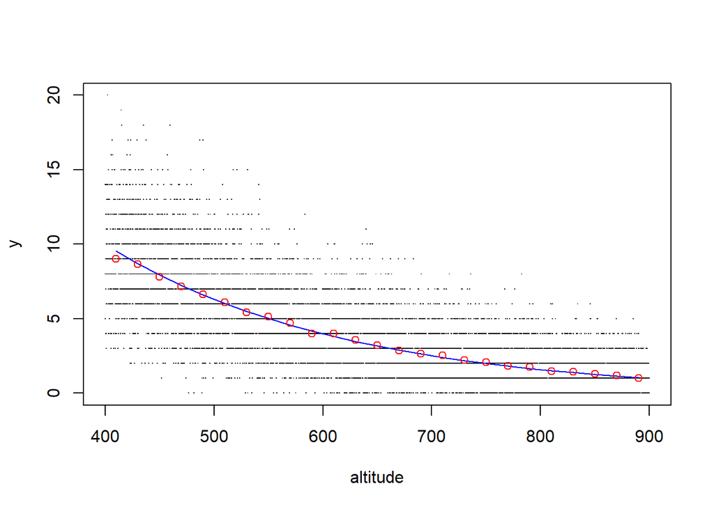

```r
plot(y ~ altitude, pch=".")

# Adding a blue line for the expectation
alt = seq(410, 890, 20)
lines(alt, exp(beta_0 + beta_1*alt), col="blue")

# Plotting means of the simulated values grouped in 20 m bins (red circles)
mean_y = rep(NA, length(alt))
var_y = rep(NA, length(alt))
for(i in 1:length(alt)){
  mean_y[i] = mean(y[altitude > alt[i]-10 & altitude < alt[i]+10])
  var_y[i] = var(y[altitude > alt[i]-10 & altitude < alt[i]+10]) # For later use
}
points(alt, mean_y, col="red")
```

Here we have also plotted $\lambda$ (the expectation) as a blue line. The red circles are means of the simulated values grouped in 20 m bins (computed in a loop). In the loop we also compute the variance for each of the 20 meter bins. Let’s plot this variance against the mean to check if the variance of the Poisson distribution really equals the mean as we said in the tutorial on the Poisson distribution.

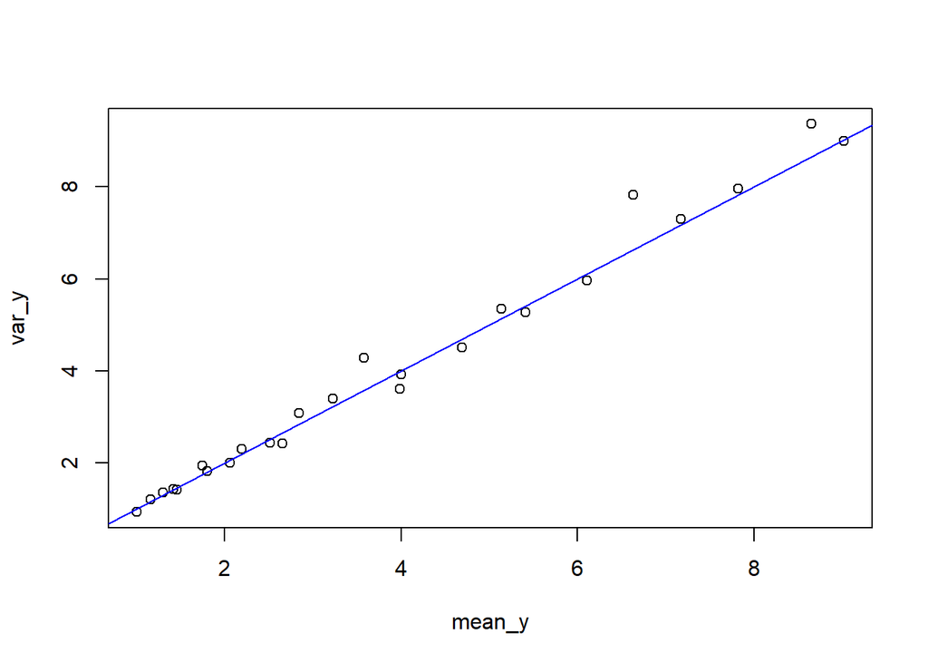

```r
plot(mean_y, var_y)
abline(0,1, col="blue")
```

The blue line is the one-to-one line (intercept = 0, slope = 1), so this looks as expected (variance = expectation).

So the data we have simulated looks like what we intended both with respect to the mean and the variance. Now we can fit the model to the simulated data to see if we can recover the parameter estimates that we fed into the model (explanations follow):

```r
fit = glm(y ~ altitude, family = poisson(link = "log"))
summary(fit)
```

```
##
## Call:
## glm(formula = y ~ altitude, family = poisson(link = "log"))
##
## Coefficients:
##               Estimate Std. Error z value Pr(>|z|)
## (Intercept)  4.085e+00  2.300e-02   177.6   <2e-16 ***
## altitude    -4.501e-03  3.963e-05  -113.6   <2e-16 ***
## ---
## Signif. codes:  0 '***' 0.001 '**' 0.01 '*' 0.05 '.' 0.1 ' ' 1
##
## (Dispersion parameter for poisson family taken to be 1)
##
##     Null deviance: 25509  on 9999  degrees of freedom
## Residual deviance: 11076  on 9998  degrees of freedom
## AIC: 39098
##
## Number of Fisher Scoring iterations: 5
```

```r
confint(fit)
```

```
##                    2.5 %       97.5 %
## (Intercept)  4.039722442  4.129882604
## altitude    -0.004578319 -0.004422978
```

```r
beta_0
```

```
## [1] 4.144653
```

```r
beta_1
```

```
## [1] -0.00460517
```

Here we have used a new model fitting function called `glm`. The first part (the “formula”) is on the same format as you are used to from `lm()`, specifying the response variable and the linear model, The next part, `family = poisson(link = "log")` specifies that we have a Poisson-distributed response variable and that we want to model the $\lambda$ parameter as a linear predictor on the log-scale (i.e., in our model we have $\log(\lambda_i) = \beta_0 + \beta_1 x_{i,1} + \beta_2 x_{i,2} + ...$). The letters ‘glm’ stands for “Generalized Linear Model” which we will talk more about in the next section.

## Generalized linear models

We have already formulated the stochastic model we simulated data from in the previous section mathematically. Let’s write it on the standard hierarchical format that we used in the Week 8 (and 3) tutorial, here also using the matrix formulation for the linear predictor with any number of predictor variables in the vector $\mathbf{x}_i$:

$$y_i \sim \text{Poisson}(\lambda_i)
\\
\log(\lambda_i) = \mathbf{x}_i \boldsymbol{\beta}$$

It is essential to note that we here *do not* log-transform the response variable. Many of the $y_i$’s are zero so log-transforming this variable results in many $-\infty$ values (for this reason there is no such thing as a “log-Poisson” distribution). Instead we log-transform the $\lambda$ parameter of the Poisson distribution. $\lambda_i$ is the expected value of $y_i$ (i.e., the mean value of $y_i$ that we would have got if we hypothetically had drawn $y_i$ infinitely many times). Unlike $y_i$, $\lambda_i$ can be any positive number, not just whole numbers (integers).

Models where we use a linear model for a transformation of a distribution-parameter is called a **Generalized Linear Model** (GLM). The function we use for the transformation in such models is called a **link function**. The model we have formulated here can be called a “Poisson GLM with log-link”, specified as `glm(formula, family = poisson(link = "log"))` in R (the parenthesis with `link = "log"` can be dropped as this is the default link function when `family = poisson`).

As another example of a GLM, in STK1000, you were introduced to the “Binomial GLM with logit-link”, which we can formulate hierarchically as

$$y_i \sim \text{Binomial}(n_i, p_i)
\\
\log \left( \frac{p_i}{1-p_i} \right) = \mathbf{x}_i \boldsymbol{\beta}$$
where $n_i$ is number of trials (not a parameter!) and $p_i$ is the probability of “success” for each independent trial. Such a model is specified in R as `glm(formula, family = binomial(link = "logit"))`

## *Offset in Poisson GLM

In the rain drop example in the tutorial on the Poisson distribution, we defined the “intensity” as the expected number of points (e.g., rain drops or number of ticks) per unit area (e.g. a square meter or chick). We can also use the Poisson distribution for the number of events occurring within time intervals when the events result from a Poisson point process. In this case, the intensity is the expected number of events per time-unit (e.g., second, hour, day, or year). The expectation in the Poisson distribution ($\lambda_i$) is the intensity times the size of the area or length of the interval. Hence, if we use the symbol $\alpha$ (Greek letter ‘alpha’) for the intensity and $A$ for the size of the area or length of the interval, we have $\lambda_i = \alpha_i A_i$. If all observations ($i$) have the same $A_i=A$ it is convenient to to use $A$ as the unit of measurement for the intensity (e.g. $A = 1$ m$^2$ if all counts $y_i$ are counts per m$^2$) such that $\lambda_i = \alpha_i$. However, for many reasons the size of areas or length of intervals often vary in the data. When this is the case, we want to create a log-linear model for the intensity $\alpha_i$ (i.e., the expectation per unit area) and not $\lambda_i$. To achieve this, we should first realize that the product $\lambda_i = \alpha_i A_i$ is equivalent to $\log(\lambda_i) = \log(\alpha_i) + \log(A_i)$. If we then use a log-linear model for $\alpha_i$ such that $\log(\alpha_i) = \mathbf{x}_i \boldsymbol{\beta}$, we get a Poisson GLM on the form

$$y_i \sim \text{Poisson}(\lambda_i)
\\
\log(\lambda_i) = \mathbf{x}_i \boldsymbol{\beta} + \log(A_i)$$

This model can be described as a “**Poisson GLM with an offset**”. In the `glm` function, we specify an offset by adding `+ offset(log(A))` in the formula (see specific example below).

[Note that many texts use $\lambda$ to denote the intensity instead of the expectation when these differ and write the above model (or similar) as $y_i \sim \text{Poisson}(\lambda_iA_i); \log(\lambda_i) = \mathbf{x}_i \boldsymbol{\beta}$. I have however here used the notation that corresponds with the definitions used by the `glm` function as well as the the distribution functions `rpois`, `dpois, etc. in R. This is also the notation used in the Wikipedia entry on the Poisson distribution.]

### *Example - flower visitation rates

To better understand what this means, let’s consider a typical situation in pollination ecological studies. To study the intensity of flower visitation by pollinating insects, observers (people or cameras) may record insects visiting a patch of flowers. The aim is then to model the flower visitation intensity (or “rate”) per flower per time. However, both the number of flowers per patch ($N_i$) and the duration of the observation period ($D_i$) may vary between patches for several reasons. If the aim of the study is to estimate how the flower visitation intensity changes with altitude, one may fit the model

$$y_i \sim \text{Poisson}(\lambda_i)
\\
\log(\lambda_i) = \beta_0 + \beta_1 x_{i,1} + \log(N_i) + \log(D_i)$$
where $x_{i,1}$ is the altitude of flower patch $i$, and the linear predictor $\beta_0 + \beta_1 x_{i,1}$ is the log of flower visitation intensity, such that flower visitation rate is $\alpha_i = \exp(\beta_0 + \beta_1 x_{i,1})$, and the expected number of observed insect visits at the patch is $\lambda_i = \alpha_i N_i D_i$.

It is essential to realize that $\log(N_i)$ and $\log(D_i)$ are *not* predictor variables in the model. There are no parameters (coefficients) associated with these variables - they are simply **offsets**. If we want to investigate whether a larger patch of flowers attracts more insects *per flower* than smaller patches, we may add $N_i$ or $\log(N_i)$ as predictor variables in the model *in addition to* having $\log(N_i)$ as an offset in the model (the role of the offset is to model the *per flower* intensity).

If we have the variables `n_visits` ($y$), `alt` ($x_1$), `n_flow` ($N$) and `dur` ($D$), we specify the above model in `glm` as `glm(n_visits ~ alt + offset(log(n_flow)) + offset(log(dur)), family = poisson)`.

It may seem natural in situations like this to just divide the response variable with e.g. number of flowers. However, this new response variable will *not* be Poisson distributed (it’s not a whole number for one thing), and it is generally not reasonable to assume that this variable would be normal distributed with a constant residual variance either (it does not comply with the assumptions of the regular linear model). So this approach is not advisable!

## Overdispersion

In the Normal distribution there are two parameters; the mean (expectation) and the standard deviation. Hence, the mean and the variance in this distribution are independent of each other; you can have any value for the variance for any value of the mean. This is not the case for the Poisson and the binomial distributions that only have one parameter. In these distributions, the variance is given entirely by the mean; if you know the mean, you also know the variance. In the Poisson distribution, as we have seen, the variance equals the mean (both are equal to the $\lambda$ parameter). Data that we model with a Poisson distribution may however have a higher variance than the fitted expectation for several reasons. For example, in the “ticks on chicks” example above, we may not have collected data on altitude. If we fit a model with only intercept to these data, we will get a variance that is much higher than the mean - below we compute these in two different ways:

```r
# From the data
mean(y)
```

```
## [1] 3.8592
```

```r
var(y)
```

```
## [1] 9.704946
```

```r
# From a fitted model
fit_0 = glm(y ~ 1, family = poisson(link = "log"))
exp(coef(fit_0))
```

```
## (Intercept)
##      3.8592
```

```r
var(residuals(fit_0, type = "response")) # There are many types of residuals in GLMs; type = "response" is what we have used before
```

```
## [1] 9.704946
```

Here we see that the variance is about 2.5 times higher than the mean, and not equal to the mean as we expect from the Poisson distribution. This is because the data ($y$) itself is not Poisson-distributed. $y$ is only Poisson distributed for *given* values of altitude. We have however fitted a model where we have assumed that $y$ is Poisson distributed *unconditional* of altitude. Since the true variance in the data is larger than what the model assumes (we say that the data are **over-dispersed**), the standard error of the parameters estimated from the model will be too small and their confidence intervals become too narrow (i.e. a 95% confidence interval will fail to cover the true value used in simulations more than 5% of the times).

To check to what degree the confidence interval is too narrow in this case, we can first compute the standard deviation of the mean directly from the data (remember from STK1000 and the Week 3 tutorial that the standard error of the mean is the standard deviation divided by the square root of the sample size):

```r
se = sd(y)/sqrt(n)
```

Due to the central limit theorem that you demonstrated in the Week 2 assignment, we also know that the mean will be normal distributed since sample size is large. Hence, we can compute a 95% confidence interval as $\pm$ 1.96 times the standard error (using 1.96 here instead of 2 since sample size is huge and we don’t want to exaggerate how wide the confidence intervals *should* be):

```r
mean(y) + c(-1.96, 1.96)*se
```

```
## [1] 3.798141 3.920259
```

Not surprisingly, the confidence interval is pretty narrow since sample size is so large.

Now we can compare this to the sample size we get from the fitted Poisson model:

```r
exp(confint(fit_0))
```

```
##    2.5 %   97.5 %
## 3.820825 3.897831
```

We see that this confidence interval is even narrower. This underestimation of uncertainty may not seem very serious in this case as the confidence interval is already so narrow. However, as we will see in the worked example below, the bias in the confidence intervals (for predictions and contrasts) due to overdispersion in the data can be substantial and this is something we should definitely worry about to avoid making over-confident conclusions.

### Causes of overdispersion (and underdispersion)

We have already seen that failure to include important predictor variables can lead to overdispersion. If the data has arisen from a complex point process (as in ecological systems) we will never be able to model all the processes that determines the expectation ($\lambda$) of the Poisson distribution. Hence, when analyzing such data, there will usually be some degree of overdispersion.

Another cause of overdispersion is when the “points” of whatever point process we are studying are not independent of each other. For example, location of individuals are often not independent of each other - individuals may “attract” each other (family, mates, cooperating individuals) and this will lead to overdispersion (there will be more areas with many and few individuals than expected, and fewer with intermediate numbers). Individuals may also “repel” each other (e.g., competitors). This will however lead to **underdispersion** (individuals are more regularly dispersed than expected - see the raindrop example). Underdispersion leads to confidence intervals that are too wide. As it is generally better to be conservative than overstating the precision, this is less of a problem than overdispersion. However, if you have underdispersed data relative to a Poisson distribution, you should ask yourself whether a model that assumes that the data has been generated from a Poisson process is the best alternative for your data.

Finally, a common cause of overdispersion in the data is **zero-inflation**, which we will briefly explain in the next section.

### *Zero-inflation

Count data often have an excess of zeros compared to what should be expected by the Poisson distribution for the given mean. Such data occurs when for example when habitat patches are either suitable for a species or not, and given that it is suitable, the number of individuals is Poisson distributed. Hierarchically, we can formulate a model for this process as

$$y_i \sim \text{Poisson}(\lambda_i z_i)
\\
\log(\lambda_i) = \mathbf{x}_i \boldsymbol{\beta}
\\
z_i \sim \text{Bernoulli}(p)$$
Here $z_i$ is a Bernoulli random variable that takes value 1 with probability $p$ and value 0 with probability $1 - p$ (a Bernoulli random variable is Binomial random variable with number of trials equal to 1). When $z_i$ is 0 (indicating e.g. that the species is not present) the Poisson expectation becomes 0 and we can only observe $y_i = 0$. When $z_i$ is 1 we have a regular log-linear Poisson model. The parameters to be estimated in this model is the parameter vector $\boldsymbol{\beta}$ and the probability $p$. The probability $p$ is however usually modeled with a logit-link (possible including predictor variables). There are several functions in R that can fit such models, so search for it when you need it!

### How to detect and assess the degree of overdispersion

In a Poisson model we don’t expect the residual variance to be constant as we do in ordinary linear models based on the Normal distribution (unless the predicted $\lambda$ is constant). In the above example it made sense to look at the residual variance only because we used a model with constant predictions (intercept only model) and hence the variance was constant. Luckily, there is another general way to easily assess whether we have overdispersed data relative to our model - we can get a good indication of this from looking at the `summary()` of the model. In the summary of the correct model fitted to the data (data generated from the model we later fitted to the data), we see that the the “Residual deviance” is 11076 and the “residual degrees of freedom” is 9998. It is not so important to know what these numbers are, but you should note that they are quite close in value (their ratio is 1.11). This is what we expect; when we have enough data, the residual deviance should not be much higher that the residual degrees of freedom. In contrast, a residual deviance that is much higher than residual degrees of freedom indicates overdispersion.

Let’s check the summary of the intercept-only model that we also fitted to these simulated data:

```r
summary(fit_0)
```

```
##
## Call:
## glm(formula = y ~ 1, family = poisson(link = "log"))
##
## Coefficients:
##             Estimate Std. Error z value Pr(>|z|)
## (Intercept)  1.35046    0.00509   265.3   <2e-16 ***
## ---
## Signif. codes:  0 '***' 0.001 '**' 0.01 '*' 0.05 '.' 0.1 ' ' 1
##
## (Dispersion parameter for poisson family taken to be 1)
##
##     Null deviance: 25509  on 9999  degrees of freedom
## Residual deviance: 25509  on 9999  degrees of freedom
## AIC: 53529
##
## Number of Fisher Scoring iterations: 5
```

Here we see that the residual deviance is 25509 and the residual degrees of freedom is 9999, and their ratio is about 2.55. Note that this ratio is almost the same as the variance/mean ratio that we computed above. This is no coincidence: The ratio between the residual deviance and degrees of freedom is an estimate of how much larger the variance is in the data relative to what is expected from the Poisson model that has been fitted - this is the case for any model (not just the intercept only model)! Note however, that with limited data, we may get a quite high ratio between the residual deviance and degrees of freedom just by chance (this can be investigated by bootstrapping).

### Remedies for overdispersion

There are several ways to deal with the problem of overdispersion. We have already mentioned the zero-inflated Poisson model that you can use if you think such a process is behind your data. We will here mention three other options (that can be combined with a zero-inflated model):

1. Using a Poisson model with random effects (Generalized Linear Mixed Effects (GLMM) models)
2. *[Using another probability distribution that allows a larger residual variance than the Poisson distribution, such as the negative binomial distribution.]
3. Fitting a “**quasi-Poisson GLM**”

Now that you have learned about mixed effects models (Week 6 of the course), you probably have a feel for what this option is about.

*[The second option of using a negative binomial distribution is actually a special case of the first option as this is equivalent to a Poisson model with a Gamma-distributed $\lambda$ (with certain constraints).]

The third option does not build on a proper probability distribution and is a “quick fix” to adjust estimates of standard errors and confidence intervals. This approach will give you the same parameter estimates and predictions (as point estimates) as the regular Poisson GLM, but instead of assuming that the variance equals the mean we just assume that the variance is *proportional* to the mean and we get an estimate of the proportionality constant. This is then used to adjust the standard errors of the parameter estimates.

The most ideal approach is usually the first (using a GLMM), unless there are special considerations leading to a negative binomial distribution. However, GLMM’s can be hard to fit to sparse data (little data or few levels of the random grouping variable(s)), so the quasi-Poisson model is a good fall back option. We will show both in the worked example below.

## Worked example on real data with overdispersion

We will here analyse a real data set that inspired the “ticks on chicks” example above. Elston et al. 2001[^1] analyzed data on sheep ticks *Ixodes ricinus* on red grouse *Lagopus lagopus scoticus* chicks along an altitude gradient in Scottland in three different years (1995 to 1997). Ectoparasites at high densities can severely affect the survival of the host species and limit its distribution. With changing climate, historic data like these are interesting as a reference, allowing new studies to address long-term trends. In such studies it is important to compare the long-term trends to year-to-year variability.

The data has been included as example data in the `lme4` package that you worked with last week. We start by loading the package and the data, and look at the description of the data:

```r
library(lme4)
data(grouseticks)
?grouseticks
```

```
## starting httpd help server ...
```

```
##  done
```

To get an overview of the data, we can make a summary (see a description of the variables in `?grouseticks`):

```r
summary(grouseticks)
```

```
##      INDEX         TICKS           BROOD         HEIGHT      YEAR
##  1      :  1   Min.   : 0.00   606    : 10   Min.   :403.0   95:117
##  2      :  1   1st Qu.: 0.00   602    :  9   1st Qu.:430.0   96:155
##  3      :  1   Median : 2.00   537    :  7   Median :457.0   97:131
##  4      :  1   Mean   : 6.37   601    :  7   Mean   :462.2
##  5      :  1   3rd Qu.: 6.00   643    :  7   3rd Qu.:494.0
##  6      :  1   Max.   :85.00   711    :  7   Max.   :533.0
##  (Other):397                   (Other):356
##     LOCATION      cHEIGHT
##  14     : 24   Min.   :-59.241
##  4      : 20   1st Qu.:-32.241
##  19     : 20   Median : -5.241
##  28     : 19   Mean   :  0.000
##  50     : 17   3rd Qu.: 31.759
##  36     : 16   Max.   : 70.759
##  (Other):287
```

The last variable cHEIGHT is a centered version of the HEIGHT variable (altitude above sea level). Centering variables simply mean that we subtract the mean. We can do it ourselves so we are in full control. Here we call the variable cALTITUDE instead:

```r
grouseticks$cALTITUDE = grouseticks$HEIGHT - mean(grouseticks$HEIGHT)
```

Centering is often done to improve convergence in the model fitting routines. In the GLMM example below, we need to use the centered variable to achieve convergence, so we will use this variable from the start. Note that centering variables *does not* change the models we are fitting; we will get exactly the same predictions, contrasts and residuals. However, the meaning of the intercept changes such that the intercept when using cALTITUDE is the predicted value at mean altitude (i.e., when HEIGHT equals mean(HEIGHT)). You should draw this on a piece of paper to make sure you understand!

Before we start with models, let’s also reuse the plotting routine we made above to plot the data with the mean values for every 20 meter altitude bin:

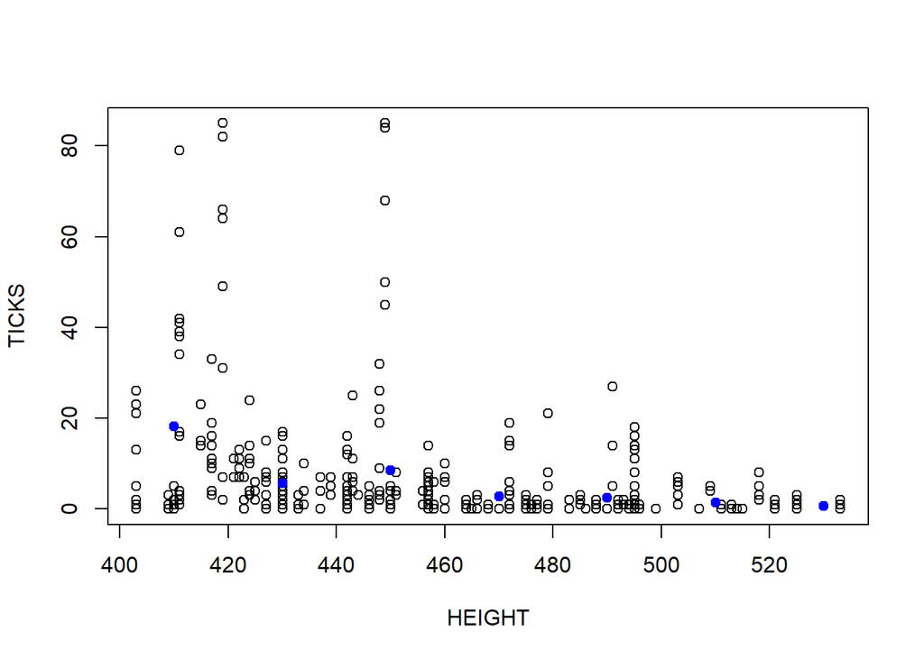

```r
plot(TICKS ~ HEIGHT, data = grouseticks)

alt = seq(410, 530, 20)
mean_y = rep(NA, length(alt))
var_y = rep(NA, length(alt))
for(i in 1:length(alt)){
  sub = grouseticks$HEIGHT > alt[i]-10 & grouseticks$HEIGHT< alt[i]+10
  mean_y[i] = mean(grouseticks$TICKS[sub])
  var_y[i] = var(grouseticks$TICKS[sub])
}
points(alt, mean_y, col="blue", pch=19)
```

… and plot the variance against the mean:

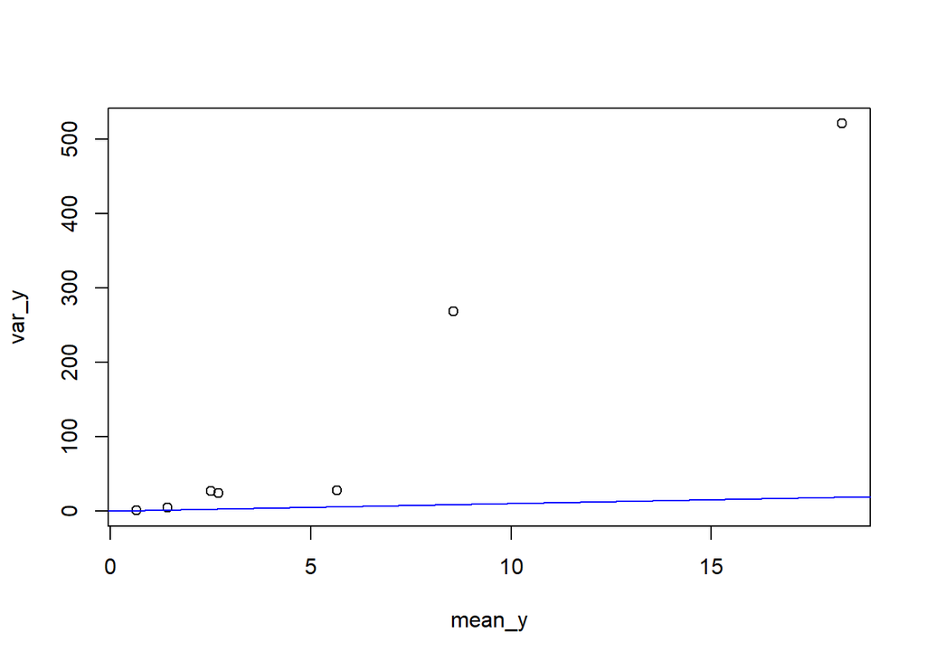

```r
plot(mean_y, var_y)
abline(0,1, col="blue")
```

Clearly, the variance is much greater than the mean (especially when the mean is high - remember that the blue line is the one-to-one line). This indicates a large overdispersion in the data. This overdispersion could however at least partly be due to variation among years. Let’s fit a Poisson GLM with both year and altitude as predictor variables and check the ratio between residual deviance and degrees of freedom (here I use a model with interaction effects):

```r
fit_yr_alt_int = glm(TICKS ~ YEAR*cALTITUDE, data = grouseticks, family = poisson)
summary(fit_yr_alt_int)
```

```
##
## Call:
## glm(formula = TICKS ~ YEAR * cALTITUDE, family = poisson, data = grouseticks)
##
## Coefficients:
##                   Estimate Std. Error z value Pr(>|z|)
## (Intercept)       0.553087   0.097972   5.645 1.65e-08 ***
## YEAR96            1.664596   0.102250  16.280  < 2e-16 ***
## YEAR97           -0.548352   0.135370  -4.051 5.11e-05 ***
## cALTITUDE        -0.058198   0.002539 -22.918  < 2e-16 ***
## YEAR96:cALTITUDE  0.044693   0.002662  16.789  < 2e-16 ***
## YEAR97:cALTITUDE  0.040453   0.003590  11.270  < 2e-16 ***
## ---
## Signif. codes:  0 '***' 0.001 '**' 0.01 '*' 0.05 '.' 0.1 ' ' 1
##
## (Dispersion parameter for poisson family taken to be 1)
##
##     Null deviance: 5847.5  on 402  degrees of freedom
## Residual deviance: 3009.0  on 397  degrees of freedom
## AIC: 3952
##
## Number of Fisher Scoring iterations: 6
```

Here we see that the residual deviance is about 8 times higher than the degrees of freedom, indicating a high overdispersion even after accounting for differences between years. We also see from the parameter estimates that there appear to be some differences among years (1995 having a steeper negative slope than the two other years and 1996 having the highest numbers of ticks per chick at the mean altitude (remember that we have centred the altitude variable)). However, due to the high overdispersion, the standard errors are much smaller than they should should be. This is something we clearly need to do something about.

### Quasi-Poisson GLM

Let’s first try the approach of fitting a quasi-Poisson GLM to the data. To do that, we simply replace `family = poisson` to `family = quasipoisson` in the call to `glm`.

```r
fit_yr_alt_int_quasi = glm(TICKS ~ YEAR*cALTITUDE, data = grouseticks, family = quasipoisson)
summary(fit_yr_alt_int_quasi)
```

```
##
## Call:
## glm(formula = TICKS ~ YEAR * cALTITUDE, family = quasipoisson,
##     data = grouseticks)
##
## Coefficients:
##                   Estimate Std. Error t value Pr(>|t|)
## (Intercept)       0.553087   0.329732   1.677  0.09426 .
## YEAR96            1.664596   0.344133   4.837 1.89e-06 ***
## YEAR97           -0.548352   0.455601  -1.204  0.22947
## cALTITUDE        -0.058198   0.008547  -6.809 3.64e-11 ***
## YEAR96:cALTITUDE  0.044693   0.008959   4.988 9.12e-07 ***
## YEAR97:cALTITUDE  0.040453   0.012081   3.349  0.00089 ***
## ---
## Signif. codes:  0 '***' 0.001 '**' 0.01 '*' 0.05 '.' 0.1 ' ' 1
##
## (Dispersion parameter for quasipoisson family taken to be 11.3272)
##
##     Null deviance: 5847.5  on 402  degrees of freedom
## Residual deviance: 3009.0  on 397  degrees of freedom
## AIC: NA
##
## Number of Fisher Scoring iterations: 6
```

Note that the text “`(Dispersion parameter for poisson family taken to be 1)`” in the first GLM summary now changed to `...taken to be 11.3272)`. This dispersion parameter (also called a “variance inflation factor”) is an estimate of how many times higher the variance in the data is relative to the residual variance assumed by the Poisson GLM, and is used for adjusting the standard errors we have in the output. The whole variance-covariance matrix has simply been multiplied by this number (you can confirm that by typing `vcov(fit_yr_alt_int_quasi)/vcov(fit_yr_alt_int)` in the Console window). Note that the point estimates of the parameters have not changed.

At this stage it would have been nice to make a plot of the prediction of tick infestation intensity ($\hat{\lambda}$) from this model, but we leave that for you to do in the Assignment.

### Including random effects (GLMM)

Ending our analysis with the quasi-Poisson model is somewhat unsatisfactory because we can get a lot more information out of the data from a GLMM. With a quasi-Poisson model we just compute a “fudge factor” (a term from physics) to adjust the variance-covariance matrix (and thereby standard errors, confidence intervals and p-values) to account for over-dispersion. With a GLMM we could decompose the extra-Poisson variation in the data into variation among locations, among broods within locations and among chicks within broods. With a GLMM we can fit the following model:

$$y_i \sim \text{Poisson}(\lambda_i)
\\
\log(\lambda_i) = \mathbf{x}_i \boldsymbol{\beta} + \delta_{l(i),L} +
\delta_{b(i),B} + \delta_{i,C}
\\
\delta_{l(i),L} \sim N(0, \sigma_L)
\\
\delta_{b(i),B} \sim N(0, \sigma_B)
\\
\delta_{i,C} \sim N(0, \sigma_C)$$

where $\mathbf{x}_i \boldsymbol{\beta}$ is the fixed effects of the model, and the $\delta$s are the random effects. The indices $l(i)$ and $b(i)$ are the location and brood of chick $i$. Note that in Poisson models (and binomial models) we can have a variance component at the level of the observations (chicks in this case). In the models based on the normal distribution this variance component would be the same as the residual variance, and we can not have two parameters for the same thing.

This model can be fitted with the `glmmTMB` function in the R package with the same name. You can use this function in much the same way as the ‘lmer’ function we used in Week 6, only adding the argument `family = poisson`. For example, to fit the above model with interacting fixed effects of `YEAR`and `cALTITUDE`, we use `glmmTMB(TICKS ~ YEAR * cALTITUDE + (1|LOCATION/BROOD/INDEX), family=poisson, data=grouseticks)`. We will not do this here, but leave it as an *optional* part of the assignment and will include it in our suggested solution.

## Exercises

Since we have been using a log-link in the worked example above, we can interpret the parameters in much the same way as the parameters in the log-linear models that we worked with last week. Use the fitted model object `fit_yr_alt_int_quasi` to answer the following questions:

1. What is the expected number of ticks per chick for each of the three years at mean altitude? Compute both point estimates and confidence intervals.
2. What is the expected number of ticks per chick for each of the three years at the lowest and highest altitude in the data? Compute both point estimates and confidence intervals.
3. How does expected number of ticks relate to altitude in each of the three years? Express the effects of altitude (slopes) in an easily interpretable way, both as point estimates and confidence intervals.

## Assignment

A. Make a plot of predicted intensity, with confidence intervals, of tick infestation ($\lambda$) from the quasi-Poisson model (`fit_yr_alt_int_quasi`) fitted in the worked example above. Make one plot with different coloured lines for each of the three years so that it is easier to interpret the the differences between years. Here are some hints to help you complete the task (if you need them - you can try without!):

- You first need to create a new data frame with the `expand.grid` function that you use for the `newdata` argument in the `predict function`. This data frame should contain all the values for the predictor variables that you want to plot the predictions for (alternatively, you can make one data frame for each year).
- Remember that you have used the centered `cALTITUDE` variable when fitting the model. In the plot, however, you want the actual altitude on the x-axis. The easiest way to do this is to first include a variable with the altitudes you want to make the predictions for (e.g. every meter between the lowest and highest altitude in the data), and then make a `cALTITUDE` variable in the data frame where you transform the altitude in the *exactly same* way as you did before fitting the model. This is a step where it is easy to go wrong, so think carefully about what you are doing (what should you subtract?). Then you can use the original altitude variable on the x-axis in your plot.
- When you use the generic `predict` function on a `glm`model object, the function you are actually using is `predict.glm` (this is called a “method” in R), although you can just use `predict()` (R figures it out based on the class of the object). You need the argument `se.fit = TRUE` to get standard errors of the predictions (unlike in `predict.lm`, you cannot get the confidence intervals out directly in `predict.glm`).
- First compute the confidence interval for the linear predictor (i.e., for $\log(\lambda)$) and then transform the interval before plotting.

B. The following questions are about the interpretations of the plot you have made - try to be critical (there are no right or wrong answers, but some answers are better than others and we may agree or disagree with your interpretations):

1. Can you say that these results indicate that there was a statistically significant decline or increase over time (years) in the density of ticks in this area? Explain. What are the possible explanations for the patterns that you see?
2. Imagine you are asked by a group of researchers to comment on their project proposal to study how the tick distribution in this area has changed since this study. They plan to re-sample the same study area during a single season. What advice would you give them?

[* C. OPTIONAL (and a bit advanced): Use `glmmTMB()` to fit the model specified as `glmmTMB(TICKS ~ YEAR * cALTITUDE + (1|LOCATION/BROOD/INDEX), family=poisson, data=grouseticks)` to the data. Make your interpretation of the estimated variances/standard deviations of the random effects. Re-use the your plot-code from part A above to make a plot of the predicted median and mean $\lambda$ from this model. Some hints:

- You need to install the `glmmTMB` package with `install.packages("glmmTMB")`.
- To make predictions for the median among locations, broods and chicks in the whole population (and not for specific or random locations, broods or chicks), include `LOCATION`, `BROOD` and `INDEX` as variables with only `NA` values in `newdata` and include the argument `re.form=~0` in `predict.glmmTMB`.
- To get predictions for the *mean* among locations, broods and chicks in the whole population you need to multiply the predictions of the median with `exp(Var/2)` (see Week 8 tutorial) where `Var` is the sum of the three random effects variances (the three variance components are assumed to be independent in the model).
[^1]: (ELSTON, D., MOSS, R., BOULINIER, T., ARROWSMITH, C., & LAMBIN, X. (2001). Analysis of aggregation, a worked example: Numbers of ticks on red grouse chicks. Parasitology, 122(5), 563-569. doi:10.1017/S0031182001007740)